# AN588 Fall 2023 Data Replication Assignment

Samantha Vee

2023-10-19

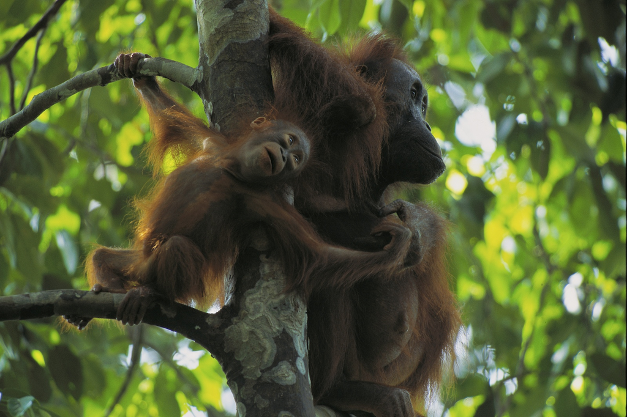

# Introduction

### Background

I am replicating the data analyses from O’Connell et al. (2019), titled “Sociosexual behavioral patterns involving nulliparous female orangutans (Pongo sp.) reflect unique challenges during the adolescent period”. Orangutans have the slowest life history of all great apes. This comes with a long period of adolescent development that lasts between 6-9 years. Because orangutans are semi-solitary with high levels of sexual coercion, adolescent females experience a unique set of challenges as they become more independent.

The purpose of this study was to determine whether adolescent female orangutans employ different mating strategies from adult female orangutans. More specifically, this paper aimed to test if there is a difference in the degree of proceptivity (quantified by mating score) between adolescent and adult females. They predicted that adolescent females will display more proceptive behavior and less frequent resistant mating behavior compared to adult females.

### Methods

The study was conducted over a one year period in Gunung Palung National Park, West Kalimantan, Indonesia. Behavioral data on social and mating interactions were collected during this time period and analyzed alongside behavioral data from the long term database (1994-2014). The sample size included 11 adolescent females, 8 adult females, 8 flanged males, and 17 unflanged males. Whenever a mating event took place, the IDs of the actors and recipients, duration of the mating event, and types of behaviors were recorded. Mating behaviors were classified as being either proceptive, receptive, or resistant depending on the combination of observed behaviors observed during the mating event (see Table 2 below).

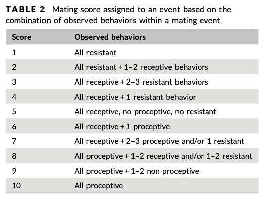

### Replication project steps

O’Connell et al. (2019) conducted their analyses with SPSS 25. I will be attempting to replicate their results in R via the following steps:  
1. Clean and load the data  
2. Calculate descriptive statistics for mating score, mating duration, and mating behavior types for adolescent and adult females.  
3. Plot the relationship between female age class (adolescent and adult) and mating score. This will be done by creating a boxplot with {ggplot2}.  
4. Use generalized linear mixed models (GLMM) with ordinal distribution to predict mating score. I will be using the clmm() function in the {ordinal} package. I will also compare my model against those containing interaction effects with likelihood ratio tests.

# Preliminaries

Here are the packages I’ll be using:

```r
library(curl)
library(tidyverse)
library(DescTools) # descriptive stats
library(ggsignif) # data visualization
library(ordinal) # glmms for ordinal data
library(AICcmodavg) # AICc model comparisons
```

I cleaned up the data in Excel before importing it into R. The original Excel file contained a lot of annotations, sheets with calculations, and columns with notes that weren’t relevant to this replication. I copied the relevant columns into a new Excel sheet, converted it into a csv file, and saved them to my repository.  
Here, I am loading the csv file into R and previewing its columns. O’Connell et al. (2019) didn’t mention what to do with NA values so I removed them from the dataset. I also converted strings to factors.

```r
f <- curl("https://raw.githubusercontent.com/samanthavee/svee-data-replication-assignment/main/Cleaned_MatingData_OConnelletal2019.csv")
matingdata <- read.csv(f, header = TRUE, sep = ",", stringsAsFactors = TRUE)
matingdata <- na.omit(matingdata)
head(matingdata)
```

```
##       date       femaleID female_class male_class mating_duration mating_score
## 2 10/24/94           Shea            1          1             540            8
## 3  11/6/94           Shea            1          1             600            9
## 4   2/4/95 EmiliaKontessa            1          1             720            2
## 5   2/4/95 EmiliaKontessa            1          1             540            8
## 6  2/21/95         Martha            1          1             450            8
## 7  1/10/98      AF10Jan98            1          2             180            3
##   mating_behavior    maleID reprod_status
## 2      proceptive       Rob       cycling
## 3      proceptive       Rob       cycling
## 4       resistant SubadultG       cycling
## 5      proceptive SubadultG       cycling
## 6      proceptive SubadultG       cycling
## 7       receptive JariManis       cycling
```

- **female_class** indicates whether the female is an adolescent (1) or adult (2).
- **male_class** indicates whether the male is unflanged (1) or flanged (2).
- **mating_score** is an ordinal variable that describes whether females were resistant (1-2), receptive (3-7), or proceptive (8-10) during a mating event. These scores are classified in the column **mating_behavior**.

# Descriptive statistical analysis

O’Connell et al. (2019) calculated descriptive statistics for mating score (mean, median, mode), mating duration (mean, median), and mating behavior types (mean, range) for adolescent and adult females.

First I need to separate the data for adolescent and adult females.

```r
adultF_data <- matingdata[matingdata$female_class == 2, ]
length(adultF_data$femaleID)
```

```
## [1] 35
```

```r
adolescentF_data <- matingdata[matingdata$female_class == 1, ]
length(adolescentF_data$femaleID)
```

```
## [1] 27
```

### Mating score

I am calculating the mean, median, and mode of mating score by adult and adolescent females. I used the {DescTools} package to calculate mode since there is no base R function that will do this.

```r
# adult
adult_ms_mean <- mean(adultF_data$mating_score)
adult_ms_med <- median(adultF_data$mating_score)
adult_ms_mode <- Mode(adultF_data$mating_score)
adult <- list(Mean = as.numeric(adult_ms_mean), Median = as.numeric(adult_ms_med), Mode = as.numeric(adult_ms_mode))

# adolescent
adol_ms_mean <- mean(adolescentF_data$mating_score)
adol_ms_med <- median(adolescentF_data$mating_score)
adol_ms_mode <- Mode(adolescentF_data$mating_score)
adolescent <- list(Mean = as.numeric(adol_ms_mean), Median = as.numeric(adol_ms_med), Mode = as.numeric(adol_ms_mode))

# bind
ms <- rbind(adult, adolescent); ms
```

```
##            Mean     Median Mode
## adult      4.257143 4      2
## adolescent 7.185185 9      9
```

- The mean mating score for adolescent females is higher than adult females. However, both values fall within the range of receptive behaviors, according to table 2.
- O’Connell et al. (2019) reports that “adolescent females had a mean mating score of 7.4 ± 2.5 (median = 8, mode = 10, range = 2–10), whereas adult females (N=8) had a mean mating score of 3.3±2.0 (median=2, mode=2, range = 1–9). The mean adolescent female sexual contact duration was 854 ± 285 s, whereas the mean adult female duration was 486 ± 65 s.”
- I was slightly confused about how I should have approached this section because O’Connell et al. ended up providing additional descriptive statistics that were not actually mentioned in the methods section (e.g. providing range here even though it wasn’t previously described). I decided to only follow what was discussed in the methods section to avoid confusion.
- My values also did not match the published results. I ended up going back to the original dataset, where I realized that the descriptive stats were calculated in Excel instead of SPSS. The data was manually pasted into a separate Excel page and descriptive stats were calculated using the built in Excel function. Each pasted chunk for adults and adolescents is missing 3 entries (excluding NAs), which explain why my values differ. It’s unclear whether these data points were accidentally or deliberately excluded. I wasn’t able to figure out which ones were excluded without individually comparing each line of data (which would have taken too long) so I proceeded with the dataset I had.

### Mating duration

I am calculating the mean and median of mating duration by adult and adolescent females.

```r
# adult
adult_md_mean <- mean(adultF_data$mating_duration)
adult_md_med <- median(adultF_data$mating_duration)
Adult <- list(Mean = as.numeric(adult_md_mean), Median = as.numeric(adult_md_med))

# adolescent
adol_md_mean <- mean(adolescentF_data$mating_duration)
adol_md_med <- median(adolescentF_data$mating_duration)
Adolescent <- list(Mean = as.numeric(adol_md_mean), Median = as.numeric(adol_md_med))

# bind
md <- rbind(Adult, Adolescent); md
```

```
##            Mean     Median
## Adult      481.5143 360
## Adolescent 794.6667 450
```

- The mean mating duration is longer for adolescent females than adult females.
- O’Connell et al. (2019) reports that “the mean adolescent female sexual contact duration 854 ± 285 s, whereas the mean adult female duration was 486 ± 65 s”.
- They did not report the median even though section 2.5 of the Methods notes that median of mating duration was calculated.
- I experienced a similar problem with the first part of calculating the descriptive stats where my calculated means are slightly different from the reported means, which may be due to missing data.

### Mating behavior type

O’Connell et al. (2019) don’t specify how this was calculated so I am doing what feels most intuitive to me. I am classifying mating scores from 1-2 as resistant, 3-7 as receptive, and 8-10 as proceptive. This is based off Table 2 from the paper.

I am using {dyplyr} to create smaller data frames for each mating behavior type for adolescent and adult females.

```r
# adults
adult_resist <- adultF_data[adultF_data$mating_behavior == "resistant", ]
adult_rec <- adultF_data[adultF_data$mating_behavior == "receptive", ]
adult_proc <- adultF_data[adultF_data$mating_behavior == "proceptive", ]

# adolescents
adol_resist <- adolescentF_data[adolescentF_data$mating_behavior == "resistant", ]
adol_rec <- adolescentF_data[adolescentF_data$mating_behavior == "receptive", ]
adol_proc <- adolescentF_data[adolescentF_data$mating_behavior == "proceptive", ]
```

Now I am going to start by calculating the mean for each mating behavior type.

```r
# adults
adult_resist_mms <- mean(adult_resist$mating_score) # resistant
adult_rec_mms <- mean(adult_rec$mating_score) # receptive
adult_proc_mms <- mean(adult_proc$mating_score) # proceptive

# adolescents
adol_resist_mms <- mean(adol_resist$mating_score) # resistant
adol_rec_mms <- mean(adol_rec$mating_score) # receptive
adol_proc_mms <- mean(adol_proc$mating_score) # proceptive

# mean
Adult <- list(Resistant = as.numeric(adult_resist_mms),
              Receptive = as.numeric(adult_rec_mms),
              Proceptive = as.numeric(adult_proc_mms))
Adolescent <- list(Resistant = as.numeric(adol_resist_mms),
                   Receptive = as.numeric(adol_rec_mms),
                   Proceptive = as.numeric(adol_proc_mms))
mean_score <- rbind(Adult, Adolescent); mean_score
```

```
##            Resistant Receptive Proceptive
## Adult      1.9       4.772727  8.333333
## Adolescent 1.75      4.8       9.055556
```

As you can see, I initially used {dyplyr} to create smaller data frames for each mating behavior type for adolescent and adult females and then calculated the mean for each. However, looking at the output for the above table helped me realize that my approach was incorrect. My calculated means will only fall within the range I constructed for each mating behavior type (resistant 1-2; receptive 3-7; proceptive 8-10). After reading the paper more closely, I noticed that Table 3 (below) states that the mean describes the *number of acts* per mating event. My dataset only contains data about types of acts, not number of acts, which is what I need to calculate this descriptive statistic. I was not able to move forward with this part of the analysis since this was not provided in the data.

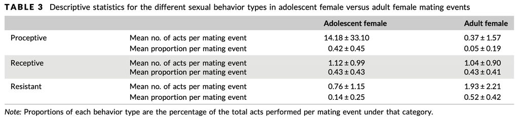

# Data visualization

I will be replicating the following figure from this paper using {ggplot2}:

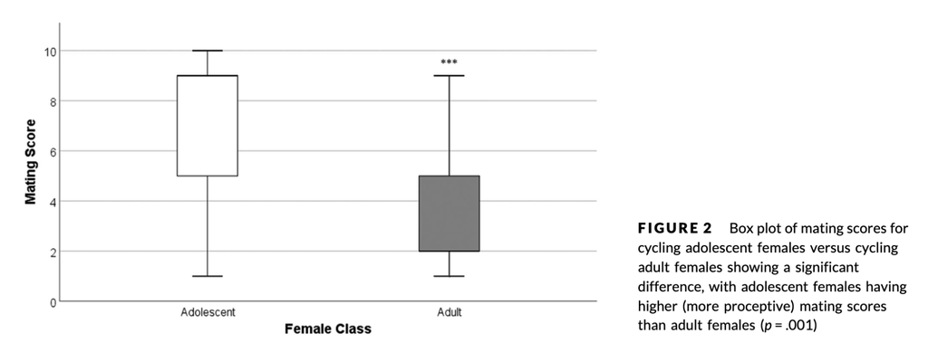

When I initially tried to make the plot, I received an error message because Female Class was an integer-type vector containing 1s and 2s. I needed to group them into Adult and Adolescent rather than numbers so I created a new factor-type vector that labeled the 1s and 2s according to their age class and added it to the original dataset.

```r
female_class_labels <- c("Adolescent", "Adult")
factor_female_class <- factor(matingdata$female_class, levels = 1:2, labels = female_class_labels)
matingdata$factor_female_class <- factor_female_class #added new vector to original dataset
head(matingdata)
```

```
##       date       femaleID female_class male_class mating_duration mating_score
## 2 10/24/94           Shea            1          1             540            8
## 3  11/6/94           Shea            1          1             600            9
## 4   2/4/95 EmiliaKontessa            1          1             720            2
## 5   2/4/95 EmiliaKontessa            1          1             540            8
## 6  2/21/95         Martha            1          1             450            8
## 7  1/10/98      AF10Jan98            1          2             180            3
##   mating_behavior    maleID reprod_status factor_female_class
## 2      proceptive       Rob       cycling          Adolescent
## 3      proceptive       Rob       cycling          Adolescent
## 4       resistant SubadultG       cycling          Adolescent
## 5      proceptive SubadultG       cycling          Adolescent
## 6      proceptive SubadultG       cycling          Adolescent
## 7       receptive JariManis       cycling          Adolescent
```

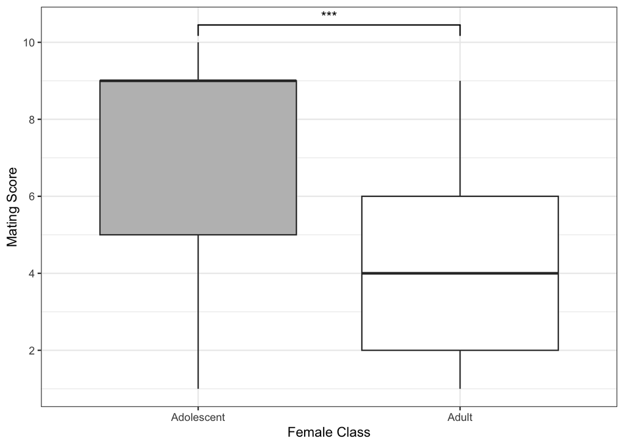

```r
fig2 <- ggplot(data = matingdata, aes(x = factor_female_class, y = mating_score,
                                      fill = factor_female_class)) +
              geom_boxplot(na.rm = TRUE, show.legend = FALSE) +
              xlab("Female Class") + ylab("Mating Score") +
              scale_y_continuous(breaks = seq(0, 10, by = 2)) +
              theme_bw() +
              geom_signif(comparisons = list(c("Adult", "Adolescent")), map_signif_level=TRUE) +
              scale_fill_manual(breaks = c("Adult", "Adolescent"), values = c("white", "grey"))
fig2
```

# GLMM with ordinal data

O’Connell et al. (2019) used a generalized linear mixed model (GLMM) with an ordinal distribution to predict the mating score. The outcome of interest, mating score, is an ordinal variable with 1 being fully resistant and 10 being fully proceptive. The types of behaviors exhibited at each level is described in Table 2 (above).

They also note that only mating events of females who were potentially cycling (not pregnant or lactating) were included. I used {dyplr} to filter out the data and push data from only cycling females into a new data frame.

```r
glmm_data <- matingdata[matingdata$reprod_status == "cycling", ]
summary(glmm_data$reprod_status) # it worked!
```

```
##                     cycling lactate_early  lactate_late      pregnant
##             0            44             0             0             0
```

## Exploring the data

Before jumping directly into the model, I want to explore the data and plot some variables.

```r
head(glmm_data)
```

```
##       date       femaleID female_class male_class mating_duration mating_score
## 2 10/24/94           Shea            1          1             540            8
## 3  11/6/94           Shea            1          1             600            9
## 4   2/4/95 EmiliaKontessa            1          1             720            2
## 5   2/4/95 EmiliaKontessa            1          1             540            8
## 6  2/21/95         Martha            1          1             450            8
## 7  1/10/98      AF10Jan98            1          2             180            3
##   mating_behavior    maleID reprod_status factor_female_class
## 2      proceptive       Rob       cycling          Adolescent
## 3      proceptive       Rob       cycling          Adolescent
## 4       resistant SubadultG       cycling          Adolescent
## 5      proceptive SubadultG       cycling          Adolescent
## 6      proceptive SubadultG       cycling          Adolescent
## 7       receptive JariManis       cycling          Adolescent
```

```r
summary(glmm_data)
```

```
##        date       femaleID   female_class     male_class  mating_duration
##  3/21/14 : 4   Marissa:10   Min.   :1.000   Min.   :1.0   Min.   : 110.0
##  1/10/98 : 3   Bibi   : 7   1st Qu.:1.000   1st Qu.:1.0   1st Qu.: 276.8
##  12/16/97: 2   Walimah: 6   Median :2.000   Median :1.5   Median : 390.0
##  2/4/95  : 2   Zarina : 4   Mean   :1.568   Mean   :1.5   Mean   : 640.9
##  3/26/14 : 2   Berani : 3   3rd Qu.:2.000   3rd Qu.:2.0   3rd Qu.: 600.0
##  1/11/98 : 1   Betsy  : 2   Max.   :2.000   Max.   :2.0   Max.   :7080.0
##  (Other) :30   (Other):12
##   mating_score      mating_behavior       maleID         reprod_status
##  Min.   : 1.000             : 0     Codet    : 7                : 0
##  1st Qu.: 2.750   proceptive:14     JariManis: 7   cycling      :44
##  Median : 5.000   receptive :19     Bosman   : 3   lactate_early: 0
##  Mean   : 5.386   resistant :11     Roman    : 3   lactate_late : 0
##  3rd Qu.: 8.000                     SubadultG: 3   pregnant     : 0
##  Max.   :10.000                     Bilbo    : 2
##                                     (Other)  :19
##  factor_female_class
##  Adolescent:19
##  Adult     :25
##
##
##
##
##
```

```r
class(glmm_data$mating_score)
```

```
## [1] "integer"
```

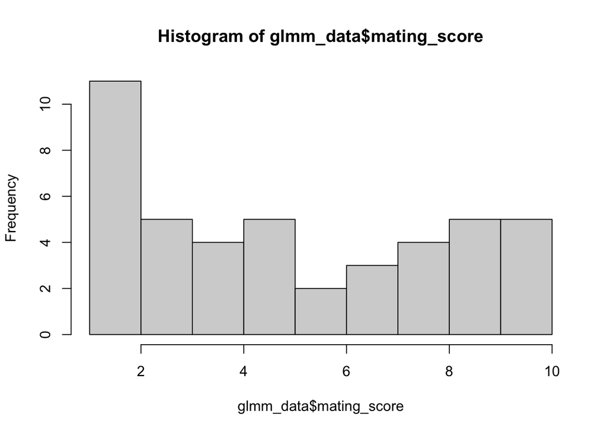

```r
hist(glmm_data$mating_score)
```

The class for the mating score variable is currently integer but it needs to be a factor since each number from 1-10 represents a different level of proceptivity. This is important for making the GLMM with ordinal data later on.

```r
glmm_data$mating_score <- as.factor(glmm_data$mating_score)
class(glmm_data$mating_score)
```

```
## [1] "factor"
```

I previously plotted female class and mating score but I want to visualize other aspects of the data so I will try plotting female class and mating duration.

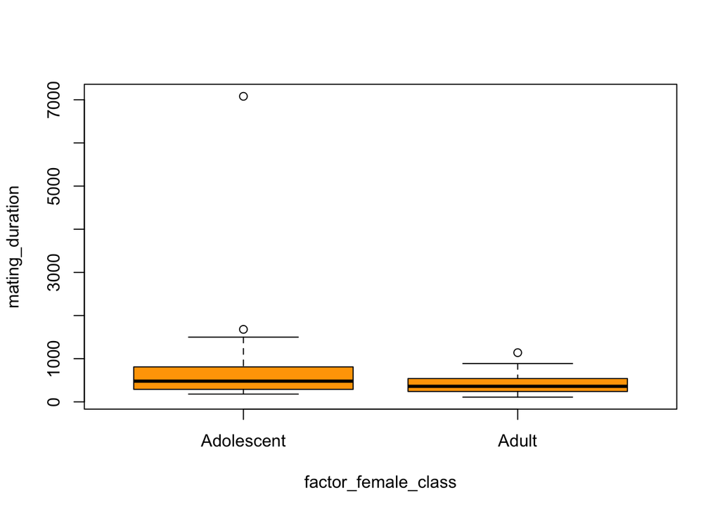

```r
plot(data = glmm_data, mating_duration ~ factor_female_class, col = c("orange"))
```

One adolescent female in particular had a very long mating event. Looking at the rest of the bars, it looks like adolescent females have slightly higher mating duration than adult females?

I also want to plot male class and mating duration. Before I do that, I need to create a new column where male class is a factor.

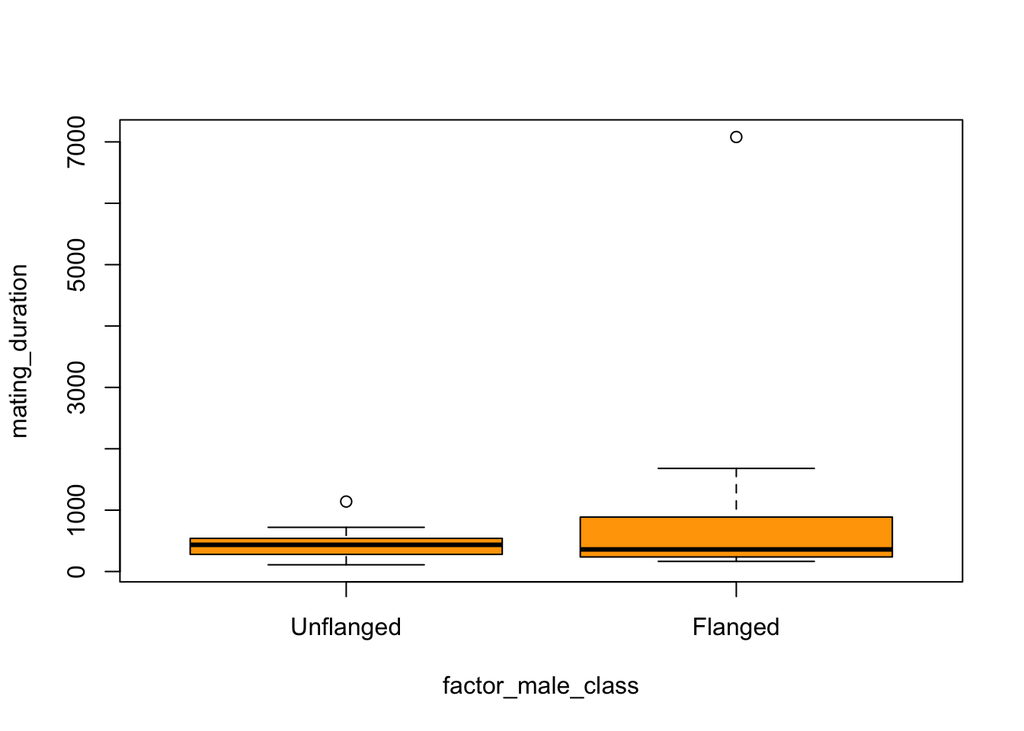

```r
male_class_labels <- c("Unflanged", "Flanged")
factor_male_class <- factor(glmm_data$male_class, levels = 1:2, labels = male_class_labels)
glmm_data$factor_male_class <- factor_male_class
plot(data = glmm_data, mating_duration ~ factor_male_class, col = c("orange"))
```

It looks like there’s a greater range of mating duration for flanged males. They also have the highest mating duration, which makes sense given what we know about flanged males (they are preferred by females).

## Selecting a link function

O’Connell et al. (2019) use GLMMs with an ordinal distribution to predict the mating score. Because my dependent/response variable, mating score, has an ordinal distribution, I will be using the clmm() function from the {ordinal} package. The paper specifies that fixed effects include female class (adolescent or adult), mating duration, and male class (flanged or unflanged). Female and male IDs were used as random effects to account for repeated measures from the same individual.

They also state that all combinations of possible two-way interactions effects were tested and subsequently omitted from the final model, as none were significant. In addition to making a GLMM to predict mating score, I will also run likelihood ratio tests to compare models containing interaction effects. I am testing the probability of actually seeing this collected data given a particular model.

I started by using relevel() to change the baseline group to match the output shown in the paper.

```r
glmm_data$factor_female_class <- relevel(glmm_data$factor_female_class, ref = "Adult")
glmm_data$factor_male_class <- relevel(glmm_data$factor_male_class, ref = "Flanged")
```

Next I created a full model without any interaction effects.

```r
full <- clmm(data = glmm_data, mating_score ~ factor_female_class + factor_male_class + mating_duration + (1|femaleID) + (1|maleID))
summary(full)
```

```
## Cumulative Link Mixed Model fitted with the Laplace approximation
##
## formula:
## mating_score ~ factor_female_class + factor_male_class + mating_duration +
##     (1 | femaleID) + (1 | maleID)
## data:    glmm_data
##
##  link  threshold nobs logLik AIC    niter     max.grad cond.H
##  logit flexible  44   -81.02 190.03 772(2315) 5.44e-01 1.6e+07
##
## Random effects:
##  Groups   Name        Variance Std.Dev.
##  maleID   (Intercept) 1.403    1.184
##  femaleID (Intercept) 0.000    0.000
## Number of groups:  maleID 20,  femaleID 15
##
## Coefficients:
##                                Estimate Std. Error z value Pr(>|z|)
## factor_female_classAdolescent  2.377832   0.865328   2.748   0.0060 **
## factor_male_classUnflanged    -0.700983   0.871343  -0.804   0.4211
## mating_duration                0.002212   0.001228   1.802   0.0716 .
## ---
## Signif. codes:  0 '***' 0.001 '**' 0.01 '*' 0.05 '.' 0.1 ' ' 1
##
## Threshold coefficients:
##      Estimate Std. Error z value
## 1|2   -3.2395     1.3656  -2.372
## 2|3   -0.2351     0.9308  -0.253
## 3|4    0.4982     0.9209   0.541
## 4|5    1.0812     0.9210   1.174
## 5|6    1.8635     0.9474   1.967
## 6|7    2.2354     0.9784   2.285
## 7|8    2.8713     1.0524   2.728
## 8|9    3.8951     1.1966   3.255
## 9|10   6.0195     1.6256   3.703
```

The values in the model summary did not match those from the paper, which made me wonder if O’Connell et al. (2019) used a different link function. They did not specify which link function they used for their GLMM but the clmm() function applies a default logit-link function. Other available link functions are probit, log-log (negative log-log), clog-log (complementary log-log), and cauchit.

Christensen (2011) stated that the log-log link function was appropriate for variables with a right skew distribution, which I saw in the histogram for mating score (scroll up). Smith & McKenna (2012) and this [link](https://bookdown.org/chua/ber642_advanced_regression/ordinal-logistic-regression.html) also suggest that the choice of link function used in an ordinal regression depends on the distribution of the ordinal outcome, in which the log-log link function is used when smaller categories or values are more probable. The histogram I previously created for the distribution of mating scores showed a right skewed distribution, in which lower mating scores were more common. Based on these sources, I am going to select the model with the log-log link function.

```r
loglog <- clmm(data = glmm_data, link = c("loglog"), mating_score ~ factor_female_class + factor_male_class + mating_duration + (1|femaleID) + (1|maleID))

summary(loglog)
```

```
## Cumulative Link Mixed Model fitted with the Laplace approximation
##
## formula:
## mating_score ~ factor_female_class + factor_male_class + mating_duration +
##     (1 | femaleID) + (1 | maleID)
## data:    glmm_data
##
##  link   threshold nobs logLik AIC    niter     max.grad cond.H
##  loglog flexible  44   -81.92 191.84 916(4395) 4.85e-01 2.2e+07
##
## Random effects:
##  Groups   Name        Variance  Std.Dev.
##  maleID   (Intercept) 1.588e+00 1.260e+00
##  femaleID (Intercept) 7.945e-12 2.819e-06
## Number of groups:  maleID 20,  femaleID 15
##
## Coefficients:
##                                 Estimate Std. Error z value Pr(>|z|)
## factor_female_classAdolescent  1.7866713  0.5992175   2.982  0.00287 **
## factor_male_classUnflanged    -0.6941932  0.7510369  -0.924  0.35532
## mating_duration                0.0010179  0.0007929   1.284  0.19920
## ---
## Signif. codes:  0 '***' 0.001 '**' 0.01 '*' 0.05 '.' 0.1 ' ' 1
##
## Threshold coefficients:
##      Estimate Std. Error z value
## 1|2  -2.04024    0.98036  -2.081
## 2|3   0.04387    0.74454   0.059
## 3|4   0.55162    0.75082   0.735
## 4|5   0.97057    0.75886   1.279
## 5|6   1.56203    0.78664   1.986
## 6|7   1.84902    0.81175   2.278
## 7|8   2.33262    0.86507   2.696
## 8|9   3.17301    0.98910   3.208
## 9|10  4.79897    1.30011   3.691
```

These values still don’t entirely match those from the paper, but they are close. This might be because some lines of data were removed for undisclosed reasons, which was the case when I was calculating descriptive stats. However, the overall interpretation still matches the paper. Female class predicts mating score (p = 0.00287) whereas male type (p = 0.35532) and mating duration (p = 0.19920) do not. Adolescent females in particular had significantly higher mating scores than adult females (β = 1.7866713, p = 0.00287).

I still need to confirm whether models with interaction effects are significant so I will compare those against this current model.

## Comparing interaction effects

The fixed effects are female class, male class, and mating duration. There are 3 possible ways to create two-way interaction effects: 1) female class * male class, 2) male class * mating duration, and 3) mating duration * female class. I created models with these different interaction effects.

```r
# female class * male class
int1 <- clmm(data = glmm_data, link = c("loglog"), mating_score ~ factor_female_class * factor_male_class + mating_duration + (1|femaleID) + (1|maleID))
summary(int1)
```

```
## Cumulative Link Mixed Model fitted with the Laplace approximation
##
## formula:
## mating_score ~ factor_female_class * factor_male_class + mating_duration +
##     (1 | femaleID) + (1 | maleID)
## data:    glmm_data
##
##  link   threshold nobs logLik AIC    niter     max.grad cond.H
##  loglog flexible  44   -81.47 192.93 986(4749) 4.59e-01 2.4e+07
##
## Random effects:
##  Groups   Name        Variance  Std.Dev.
##  maleID   (Intercept) 1.405e+00 1.185e+00
##  femaleID (Intercept) 2.610e-12 1.616e-06
## Number of groups:  maleID 20,  femaleID 15
##
## Coefficients:
##                                                            Estimate Std. Error
## factor_female_classAdolescent                             2.0595519  0.6495131
## factor_male_classUnflanged                               -0.3336486  0.8093489
## mating_duration                                           0.0010413  0.0007906
## factor_female_classAdolescent:factor_male_classUnflanged -1.0978621  1.1367985
##                                                          z value Pr(>|z|)
## factor_female_classAdolescent                              3.171  0.00152 **
## factor_male_classUnflanged                                -0.412  0.68016
## mating_duration                                            1.317  0.18779
## factor_female_classAdolescent:factor_male_classUnflanged  -0.966  0.33417
## ---
## Signif. codes:  0 '***' 0.001 '**' 0.01 '*' 0.05 '.' 0.1 ' ' 1
##
## Threshold coefficients:
##      Estimate Std. Error z value
## 1|2   -1.8358     0.9586  -1.915
## 2|3    0.1834     0.7425   0.247
## 3|4    0.7012     0.7508   0.934
## 4|5    1.1138     0.7575   1.470
## 5|6    1.6943     0.7828   2.164
## 6|7    1.9742     0.8061   2.449
## 7|8    2.4455     0.8559   2.857
## 8|9    3.2808     0.9774   3.357
## 9|10   4.9471     1.3070   3.785
```

```r
# male class * mating duration
int2 <- clmm(data = glmm_data, link = c("loglog"), mating_score ~ factor_female_class + factor_male_class * mating_duration + (1|femaleID) + (1|maleID))
summary(int2)
```

```
## Cumulative Link Mixed Model fitted with the Laplace approximation
##
## formula:
## mating_score ~ factor_female_class + factor_male_class * mating_duration +
##     (1 | femaleID) + (1 | maleID)
## data:    glmm_data
##
##  link   threshold nobs logLik AIC    niter     max.grad cond.H
##  loglog flexible  44   -76.18 182.37 985(4688) 5.16e-01 3.4e+07
##
## Random effects:
##  Groups   Name        Variance  Std.Dev.
##  maleID   (Intercept) 1.636e+00 1.279e+00
##  femaleID (Intercept) 2.939e-11 5.421e-06
## Number of groups:  maleID 20,  femaleID 15
##
## Coefficients:
##                                             Estimate Std. Error z value
## factor_female_classAdolescent               2.249443   0.693416   3.244
## factor_male_classUnflanged                  2.480087   1.330856   1.864
## mating_duration                             0.002760   0.001172   2.355
## factor_male_classUnflanged:mating_duration -0.007087   0.002612  -2.713
##                                            Pr(>|z|)
## factor_female_classAdolescent               0.00118 **
## factor_male_classUnflanged                  0.06239 .
## mating_duration                             0.01850 *
## factor_male_classUnflanged:mating_duration  0.00666 **
## ---
## Signif. codes:  0 '***' 0.001 '**' 0.01 '*' 0.05 '.' 0.1 ' ' 1
##
## Threshold coefficients:
##      Estimate Std. Error z value
## 1|2   -2.0296     1.2982  -1.563
## 2|3    1.0148     0.9074   1.118
## 3|4    1.5565     0.9140   1.703
## 4|5    1.9852     0.9235   2.150
## 5|6    2.5889     0.9549   2.711
## 6|7    2.8865     0.9825   2.938
## 7|8    3.4141     1.0470   3.261
## 8|9    4.3333     1.1834   3.662
## 9|10   6.5312     1.6987   3.845
```

```r
# mating duration * female class
int3 <- clmm(data = glmm_data, link = c("loglog"), mating_score ~ factor_female_class * mating_duration + factor_male_class + (1|femaleID) + (1|maleID))
summary(int3)
```

```
## Cumulative Link Mixed Model fitted with the Laplace approximation
##
## formula:
## mating_score ~ factor_female_class * mating_duration + factor_male_class +
##     (1 | femaleID) + (1 | maleID)
## data:    glmm_data
##
##  link   threshold nobs logLik AIC    niter      max.grad cond.H
##  loglog flexible  44   -77.97 185.94 1131(4533) 1.14e+00 2.5e+07
##
## Random effects:
##  Groups   Name        Variance  Std.Dev.
##  maleID   (Intercept) 1.077e+00 1.038e+00
##  femaleID (Intercept) 6.449e-12 2.540e-06
## Number of groups:  maleID 20,  femaleID 15
##
## Coefficients:
##                                                Estimate Std. Error z value
## factor_female_classAdolescent                 -0.254851   0.943373  -0.270
## mating_duration                               -0.001963   0.001461  -1.343
## factor_male_classUnflanged                    -0.727157   0.670509  -1.084
## factor_female_classAdolescent:mating_duration  0.005044   0.002103   2.398
##                                               Pr(>|z|)
## factor_female_classAdolescent                   0.7870
## mating_duration                                 0.1792
## factor_male_classUnflanged                      0.2781
## factor_female_classAdolescent:mating_duration   0.0165 *
## ---
## Signif. codes:  0 '***' 0.001 '**' 0.01 '*' 0.05 '.' 0.1 ' ' 1
##
## Threshold coefficients:
##      Estimate Std. Error z value
## 1|2   -3.5262     1.3911  -2.535
## 2|3   -1.1467     0.8050  -1.424
## 3|4   -0.6655     0.7990  -0.833
## 4|5   -0.2600     0.7972  -0.326
## 5|6    0.3024     0.8112   0.373
## 6|7    0.5675     0.8274   0.686
## 7|8    1.0293     0.8644   1.191
## 8|9    1.8548     0.9595   1.933
## 9|10   3.9432     1.3421   2.938
```

Now that I created all the models with interactions effects, I am going to compare each of them against the full model without interaction effects. The {ordinal} package includes an anova() function that performs likelihood ratio tests from the clmm() function output.

```r
anova(loglog, int1)
```

```
## Likelihood ratio tests of cumulative link models:
##
##        formula:
## loglog mating_score ~ factor_female_class + factor_male_class + mating_duration + (1 | femaleID) + (1 | maleID)
## int1   mating_score ~ factor_female_class * factor_male_class + mating_duration + (1 | femaleID) + (1 | maleID)
##        link:  threshold:
## loglog loglog flexible
## int1   loglog flexible
##
##        no.par    AIC  logLik LR.stat df Pr(>Chisq)
## loglog     14 191.84 -81.919
## int1       15 192.93 -81.466  0.9053  1     0.3414
```

```r
anova(loglog, int2)
```

```
## Likelihood ratio tests of cumulative link models:
##
##        formula:
## loglog mating_score ~ factor_female_class + factor_male_class + mating_duration + (1 | femaleID) + (1 | maleID)
## int2   mating_score ~ factor_female_class + factor_male_class * mating_duration + (1 | femaleID) + (1 | maleID)
##        link:  threshold:
## loglog loglog flexible
## int2   loglog flexible
##
##        no.par    AIC  logLik LR.stat df Pr(>Chisq)
## loglog     14 191.84 -81.919
## int2       15 182.37 -76.184   11.47  1  0.0007074 ***
## ---
## Signif. codes:  0 '***' 0.001 '**' 0.01 '*' 0.05 '.' 0.1 ' ' 1
```

```r
anova(loglog, int3)
```

```
## Likelihood ratio tests of cumulative link models:
##
##        formula:
## loglog mating_score ~ factor_female_class + factor_male_class + mating_duration + (1 | femaleID) + (1 | maleID)
## int3   mating_score ~ factor_female_class * mating_duration + factor_male_class + (1 | femaleID) + (1 | maleID)
##        link:  threshold:
## loglog loglog flexible
## int3   loglog flexible
##
##        no.par    AIC  logLik LR.stat df Pr(>Chisq)
## loglog     14 191.84 -81.919
## int3       15 185.94 -77.968   7.902  1   0.004938 **
## ---
## Signif. codes:  0 '***' 0.001 '**' 0.01 '*' 0.05 '.' 0.1 ' ' 1
```

int2 and int3, which represent models with interaction effects for male class * mating duration (p = 0.0007074) and mating duration * female class (p = 0.004938), respectively, are both significant. This suggests that these models with these interaction effects are a better fit for the data than the ‘null’ model lacking these interaction effects. This is different from O’Connell et al.’s paper, which found no significant two-way interaction effects. Again, this may come from potentially missing data (see previous explanations).

Since the original model lacking interaction effects is no longer the best fit for the data, I used AICc through the {AICcmodavg} package to compare models and confirm that ‘int2’ with the lowest p-value is the best model. I left out the ‘int1’ model because it was not significant.

```r
print(aictab(list(full, loglog, int2, int3), c("full", "loglog", "int2", "int3")))
```

```
##
## Model selection based on AICc:
##
##         K   AICc Delta_AICc AICcWt Cum.Wt     LL
## int2   15 199.51       0.00   0.78   0.78 -76.18
## int3   15 203.08       3.57   0.13   0.91 -77.97
## full   14 204.52       5.01   0.06   0.97 -81.02
## loglog 14 206.32       6.81   0.03   1.00 -81.92
```

## Interpreting the GLMM

Compared to the other models, ‘int2’ is the best fit for this dataset because it has the lowest AICc value. This model contains the interaction effect between male class and mating duration.

```r
summary(int2)
```

```
## Cumulative Link Mixed Model fitted with the Laplace approximation
##
## formula:
## mating_score ~ factor_female_class + factor_male_class * mating_duration +
##     (1 | femaleID) + (1 | maleID)
## data:    glmm_data
##
##  link   threshold nobs logLik AIC    niter     max.grad cond.H
##  loglog flexible  44   -76.18 182.37 985(4688) 5.16e-01 3.4e+07
##
## Random effects:
##  Groups   Name        Variance  Std.Dev.
##  maleID   (Intercept) 1.636e+00 1.279e+00
##  femaleID (Intercept) 2.939e-11 5.421e-06
## Number of groups:  maleID 20,  femaleID 15
##
## Coefficients:
##                                             Estimate Std. Error z value
## factor_female_classAdolescent               2.249443   0.693416   3.244
## factor_male_classUnflanged                  2.480087   1.330856   1.864
## mating_duration                             0.002760   0.001172   2.355
## factor_male_classUnflanged:mating_duration -0.007087   0.002612  -2.713
##                                            Pr(>|z|)
## factor_female_classAdolescent               0.00118 **
## factor_male_classUnflanged                  0.06239 .
## mating_duration                             0.01850 *
## factor_male_classUnflanged:mating_duration  0.00666 **
## ---
## Signif. codes:  0 '***' 0.001 '**' 0.01 '*' 0.05 '.' 0.1 ' ' 1
##
## Threshold coefficients:
##      Estimate Std. Error z value
## 1|2   -2.0296     1.2982  -1.563
## 2|3    1.0148     0.9074   1.118
## 3|4    1.5565     0.9140   1.703
## 4|5    1.9852     0.9235   2.150
## 5|6    2.5889     0.9549   2.711
## 6|7    2.8865     0.9825   2.938
## 7|8    3.4141     1.0470   3.261
## 8|9    4.3333     1.1834   3.662
## 9|10   6.5312     1.6987   3.845
```

Female class (p = 0.00118) is a significant predictor of mating score. More specifically, adolescent female is the slope/β coefficient for the effect of female class so the positive 2.249443 value suggests that mating score is greater by 2.249443 units for adolescent females than adult females. Mating duration is also a moderate, but significant predictor of mating score that can be interpreted the same way as female class. Taken together, adolescent females and higher mating duration both increase mating score, indicating higher proceptivity.

For comparison, O’Connell et a. (2019) reported: “Female class significantly predicted mating score (p = .001), whereas male type (flanged or unflanged) and mating duration did not significantly predict mating score (p = .309 and p = .181, respectively). Adolescent female mating events (N = 19) had significantly higher mating scores (indicating more proceptivity) than did those of adult females (N=26; β=1.948, p=.001).”

We both found that female class significantly predicted mating score while male type did not. However, I found a significant effect for mating duration which O’Connell et al. did not find. It makes sense that adolescent female orangutans are more proceptive than adult females. They are younger and nulliparous, making them less attractive to males; being more proceptive may make males more willing to mate with them. They may also be more proceptive as a way to familiarize themselves with males and assess how coercive they are. It also makes sense that mating duration increases mating proceptivity, as matings involving adolescent female orangutans are exceptionally long. This can be interpreted as there being a high degree of investment in matings and developing relationships with male orangutans, particularly flanged males, by adolescent females.

I also found a significant interaction effect between male class and mating duration (β=-0.007087, p = 0.00666). In order to better interpret this, I plotted the mating duration and mating score for flanged and unflanged males below:

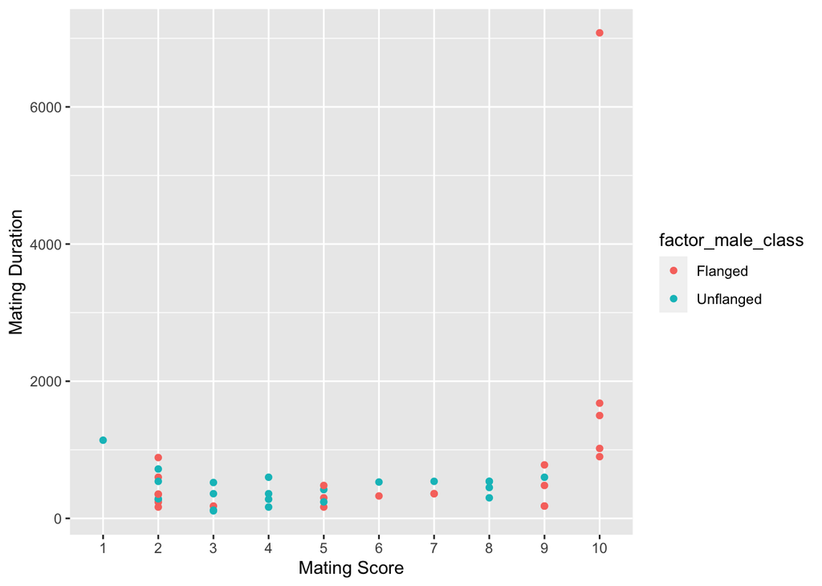

```r
glmm_data$mating_score <- as.factor(glmm_data$mating_score)

interaction <- ggplot(data = glmm_data,
                      aes(x = mating_score, y = mating_duration, fill = factor_male_class)) +
                      geom_point(aes(colour = factor_male_class)) +
                      xlab("Mating Score") + ylab("Mating Duration") +
                      scale_x_discrete(labels=c("1","2","3","4","5","6","7","8","9","10"))
interaction
```

It seems like being an unflanged male decreases mating duration (?). However, there is one outlier that may be skewing the overall effect of mating duration in mating score for flanged males. Although this interaction effect is significant (p = 0.00666), the effect itself seems minimal (β=-0.007087)

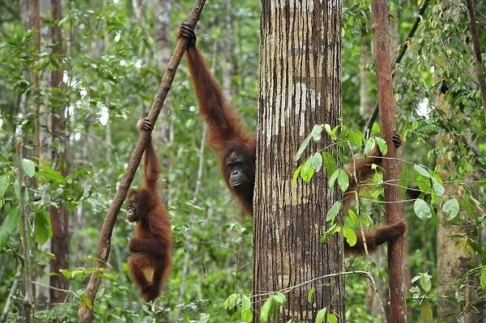

# Final reflections

I did find support for O’Connell et al.’s finding that adolescent female mating events had significantly higher mating scores than adult females. The methods seemed simple and straightforward when I initially read the paper. However, I ran into a lot of unexpected problems throughout the replication assignment. I received the raw data from the first author because it was not originally made publicly available. The raw file contained a lot of additional information that was not immediately relevant to my analyses. I cleaned up the data on my own, which may have contributed to the mismatch between my statistics and what was published. While working on the descriptive statistics, I realized that the authors removed some lines of data, but I was unable to identify which ones because this was not described in the paper. This also potentially affected my GLMM results. My model summary values did not exactly match and I also found some models with interaction effects were significant, which O’Connell et al. did not find. I assume that the results from our analyses would be more similar if I accessed a more ‘polished’ version of the data. I also thought the paper could have included more detail about the GLMM, particularly in regards to which link function they used. This project highlighted the importance of being as specific as possible when describing methods in scientific publications, which contributes to its reproducibility and replicability.

# References

Christensen, R. H. B. (2011). Analysis of ordinal data with cumulative link models—estimation with the R-package ordinal. R-package version, 28, 406.

Christensen, R. H. B. (2018). Cumulative link models for ordinal regression with the R package ordinal. Submitted in J. Stat. Software, 35.

O’Connell, C. A., Susanto, T. W., & Knott, C. D. (2020). Sociosexual behavioral patterns involving nulliparous female orangutans (Pongo sp.) reflect unique challenges during the adolescent period. American Journal of Primatology, 82(11), e23058.

Smith, T. J., & McKenna, C. M. (2012). An examination of ordinal regression goodness-of-fit indices under varied sample conditions and link functions. Multiple Linear Regression Viewpoints, 38(1), 1-7.